# Developing Data Produts Course Project Presentation

5/17/2020

## MPG Predition App

- This app predicts MPG using two types of regression models:
  - Linear model
  - Parabolic model including 2nd order variables
- The “mtcars” dataset was utilized to develop the regression models.
- The two most important parameters (weight and horsepower) are used to predict MPG.
- The interaction of the two variables (wt and hp) were not included.

## mtcars dataset overview

Based on the graph below we can see mpg’s relationship with wt and hp.

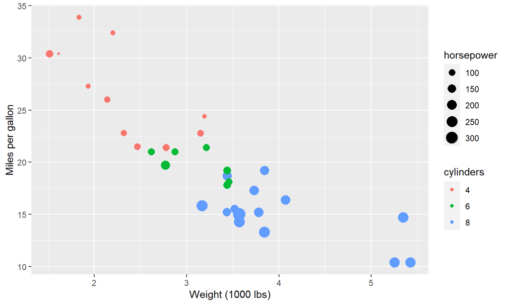

## MPG Prediction App Access Link

- The final version of the app is located on the Shiny Apps server and can be accessed through the link below

https://amanafpour.shinyapps.io/DevDataProds_CourseProject/

- A complete explanation of the app options is also included in the sidebar to provide a more user-friendly experience for those who may not be familiar with the terms included in the app.
- The app is formatted into a sidebar panel containing options and a main panel with prediction results.
- The app is also light and quick to load through any browser.

## Final Words on MPG Prediction App

- All other variables except (wt and hp) were statistically insignificant in both regression models.
- The 2nd order model resulted in a better visual fit compared to the linear model.
- The interaction of the two variables (wt*hp) was not considered in the models and so the inclusion of the hp parameter only results in a intercept change but the slope of the graph stays the same.
- The app can be further customized and refined based on more data points in the future.
- Thanks for viewing my app!